# Multimedia Data Compression

### Why to compress?

- Data compression can reduce the memory requirements of (almost) any kind of information source.

### Which data?

- Mainly ... audio, image, and video signals.

### Why these sources?

- After the digitalization of any signal we get a sequence $s[]$ of samples that represent the signal $s$ with more or less fidelity.
- Usually, $s[]$ is encoded using PCM (Pulse Code Modulation), in which every sample $s[i]$ is represented with the same number of bits.
- Most digital PCM signals are memory demanding. For example, in a CD we have a data-rate of

\begin{equation} (16+16)\frac{\text{bits}}{\text{sample}}\times 44{.}100\frac{\text{samples}}{\text{second}}= 1{.}411{.}200\frac{\text{bits}}{\text{second}}. \end{equation}

- Image and video signals require much more memory.

### Lab (audio comparison)

Compress a WAV audio file to MP3 with LAME at 128 kbps. Decompress to obtain again a WAV file. Substract the original and the decompressed WAVs and listen it.

### Lab

Compare two images, a original and a decompressed one.

```python
!pwd
!if [ ! -f Homer.png ]; then \
  echo Homer.png not found; \
  wget http://www.hpca.ual.es/~vruiz/images/Homer.png; \
else \
  echo "Homer.png found :-)"; \
fi
```

```
/tmp/data_compression_motivation
Homer.png found :-)
```

[figure not shown]

```python
import IPython
#from IPython.display import Image
IPython.display.Image("Homer.png")
```

```python
!echo `wc -c < Homer.png` bytes
```

```
374512 bytes
```

```python
!convert -quality 40 Homer.png Homer.jp2
!convert Homer.jp2 Homer_jp2.png

# Note: in OSX, install imagemagick with: "brew install imagemagick --with-openjpeg"

# Note: in Debian's, install with:
#
# sudo apt-get remove imagemagick
# sudo apt-get install pkg-config
# sudo apt-get install libjpeg-dev
# sudo apt-get install libpng-dev
# sudo apt-get install libopenjp2-7-dev
# sudo apt-get install libx11-dev
# sudo apt-get install build-essential
# sudo apt-get build-dep imagemagick -y
# wget http://www.imagemagick.org/download/ImageMagick.tar.gz
# tar xzvf ImageMagick.tar.gz
# cd ImageMagick<tab>
# ./configure --with-openjp2=yes --with-png=yes --with-jpeg=yes --with-x=yes
# Revise in the configure's output that the required delegates has been seen by ImageMagick.
# make
# sudo make install
#
# PATH=$PATH:/usr/local/bin
# convert --version
# # if error:
# sudo ldconfig /user/local/lib
#
# identify -list format | grep -i JP2
#      JP2* rw-   JPEG-2000 File Format Syntax (2.1.0)
```

[figure not shown]

```python
IPython.display.Image("Homer_jp2.png")
```

```python
!echo `wc -c < Homer.jp2` bytes
```

```
28642 bytes
```

```python
# Be sure that: "pip install pillow" was run
from PIL import Image, ImageChops, ImageOps
```

```python
orig = Image.open('Homer.png')
comp = Image.open('Homer_jp2.png')
diff = ImageChops.subtract(orig, comp)
diff = ImageOps.equalize(diff)
diff.save('diff.png')
```

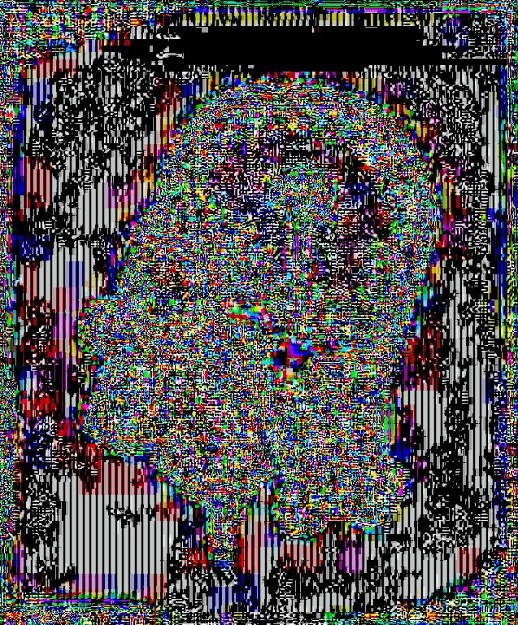

```python
IPython.display.Image("diff.png")
```

## Memory requirements of PCM video

- In RGB (PCM) video, each color pixel need at least 24 bpp (bits/pixel).
- The memory requirements of RGB video are enormous. For example, an hour of $640\times 480\times 25$ Hz true-color of PCM video needs:

\begin{equation} 25\frac{\text{images}}{\text{second}}\times 640\cdot 480\frac{\text{pixels}}{\text{image}}\times 24\frac{\text{bits}}{\text{pixel}}= 184{.}320{.}000\frac{\text{bits}}{\text{second}} \end{equation}

\begin{equation} 184{.}320{.}000\frac{\text{bits}}{\text{second}} \times 3{.}600\frac{\text{seconds}}{\text{hour}} \times \frac{1~\text{G}}{1{.}024^3}\times \frac{1~\text{byte}}{8~\text{bits}} \approx 77~\text{Gbytes} \end{equation}

- Video coding techniques should be used to compress this data. Most of these techniques are bases on Block-based Motion Estimation.

### Redundancy in signals

In general, signals has three types of redundancy:

1. **Spatial/temporal redundancy**: Produced by similarities between adjacent (in 2D and 3D) samples. It can be removed using spatial/temporal models of the signal, generating [*lossless codecs*](https://en.wikipedia.org/wiki/Lossless_compression). These codecs are known as lossless *audio*, *image*, and *video* codecs.
2. **Statistical redundancy**: Spatial/temporal redundancy generates *probabilistic relationships* among samples. Statistical redundancy can be removed by using probabilistic models, producing also *lossless codecs*. These codecs are known as *text codecs* because can be used to compress text sources.
3. **Psychological redundancy**: Part of the information that signals carry can not be perceived by humans. [*Lossy codecs*](https://en.wikipedia.org/wiki/Lossy_compression) remove this kind of pseudo-redundancy, basically, by means of quantization. Lossy codecs removes irrelevancy based on some perceptual criteria.

### Some interesting compression insights

- Lossless compressors are [bijective functions](https://en.wikipedia.org/wiki/Bijection) which find a different output for each possible input. For this reason, text compressors are lossless by definition.

[figure not shown]

- Lossy compressors are [surjective functions](https://en.wikipedia.org/wiki/Surjective_function) and therefore, two or more inputs can produce the same output. There are lossless audio, image, and video compressors, but most of them are lossy (although some of them can be lossless if quantization is not used).

[figure not shown]